# Grupo II - Avaliação de indicadores de práticas de saúde em relação a variáveis socioeconômicas

# 1 Introdução

A adoção de estratégias de práticas de saúde no ambiente escolar ou em comunidades mais amplas oferece inúmeros benefícios à população atendida. Nesse contexto, diante de um cenário marcado por desigualdades sociais e heterogeneidade nos indicadores socioeconômicos, a avaliação da relação entre esses indicadores e o contexto socioeconômico regional torna-se essencial. Tal análise é fundamental para promover maior eficiência no planejamento e na implementação de políticas públicas, além de possibilitar comparações entre diferentes regiões e o país de forma abrangente.

Desta forma, a presente pesquisa possui o objetivo de avaliar a relação dos indicadores socioeconomicos com os indicadores de práticas de saúde no ano de 2023 no Brasil.

# 2 Objetivo

O presente estudo possui o objetivo de verificar a relação entre os indicadores socioeconômicos com indicadores sínteses de promoção à saúde .

# 3 Referencial Teórico

# 3.1 Estudos de práticas de promoção à saúde

A OMS (Organização mundial da saúde) por meio da carta de Ottawa define a promoção à saúde como processo de capacitação da comunidade para atuar na melhoria de sua qualidade de vida e saúde, incluindo uma maior participação no controle deste processo. Esta definição apresenta um caráter mais amplo pois impacta os elementos que afetam a qualidade de vida das pessoas, englobando assim aspectos econômicos, sociais educacionais, lazer etc.

A promoção à saúde é um tema de alta relevância nas políticas públicas sanitárias. A mudança de paradigma nos conceitos de definição de saúde e na sua abordagem trouxeram novas perspectivas no desenvolvimento de soluções sanitárias para a sociedade. Desta forma, Heidman et. al (2006) destaca o caráter intersetorial e a elaboração de políticas públicas como pilares da promoção à saúde. Além disso dentro do contexto latino-americano, a promoção à saúde se torna mais relevante por oferecer ferramentas que proporcionam maior equidade no acesso as soluções sanitárias.

Neste contexto, como práticas a promoção a saúde temos os seguintes grupos de indicadores:

- Indicadores de temas de saúde;
- Indicadores de práticas de saúde;
- Indicadores de práticas de promoção a saúde nas escolas

Como pontos positivos para as praticas de promoção a saúde nas escolas, Baggio et al (2019) destacam que o programa pode proporcionar interação entre saúde, escola e família e consequente vinculação desta última à Unidade Básica de Saúde, permeada pela interação colaborativa entre profissionais de saúde e educação. Problemas na implantação do PSE são capazes de fornecer subsídios para a compreensão de cenários, como restrita articulação na gestão dos entes federal e municipal, bem como a fragilidade na articulação entre os setores de educação e saúde.

Assim, o impacto das políticas públicas afeta de maneira relevante a saúde de uma comunidade. Neste contexto, Buss et.al (2020) destacam que os profissionais de saúde, os movimentos sociais e as organizações populares, políticos e autoridades públicas têm responsabilidades sobre as repercussões positivas ou negativas que as políticas públicas têm sobre a situação de saúde e as condições de vida. A estratégia dos municípios saudáveis é uma das iniciativas que pode proporcionar a promoção da saúde através da ação intersetorial.

Nesta linha, o Ministério da Saúde (2010), afirma a promoção da saúde é uma estratégia de interligada transversalmente na qual se verifica visibilidade aos fatores que colocam a saúde da população em risco e às diferenças entre necessidades, territórios e culturas presentes no nosso país, visando à criação de instrumentos e procedimentos que reduzam as situações de vulnerabilidade, defendam radicalmente a equidade e incorporem a participação e o controle sociais na gestão das políticas públicas. De forma complementar, Buss (2000) destaca que a relações intersetorial e entre população e o Estado, assim como a qualificação para o exercício da cidadania e do controle social são contribuições relevantes que o exercício da promoção da saúde, por profissionais e ativistas da saúde, pode trazer para a sociedade.

Em relação aos benefícios trazidos pela promoção à saúde para a comunidade, Pinheiro et. al (2023) destaca a relevância da educação em saúde como instrumento para prevenção e promoção da saúde da sociedade. As atividades educacionais, apresentaram um grande potencial de influência na adesão de comportamentos saudáveis de vida com o objetivo de prevenir de doenças e promover o bem-estar, uma vez que as estratégias utilizadas, como as orientações verbais, uso de cartazes e distribuição de panfletos possibilitaram a ampliação de conhecimento e aproximação dos estudantes com a população.

# 4 Metodologia

O presente estudo possui uma abordagem de pesquisa quantitativa e, em relação a seu objetivo, esta pesquisa possui um perfil exploratório, uma vez que apresentará o resultado da análise quantitativa da relação dos indicadores socioeconômicos com os indicadores síntese de práticas de saúde.

Os dados socioeconômicos tiveram como período de referência o ano de 2023 e foram coletados por meio dos pacote `ipeadataR` e `Sidrar` e importados para o RStudio. Foram coletadas as seguintes variáveis:

- IDHM (Estados, Regional e Federal);
- PIB a preços de mercado (Estados, Municípios, Regional e Federal);
- PIB per Capita (Municípios, Estados, Regional e Federal);
- Índice de Gini (Estados, Regional e Federal);
- Índice de Vulnerabilidade Social (Estados, Regional e Federal).

No que diz respeito aos indicadores síntese de práticas de saúde, foram coletados a partir dos dados disponibilizados pela Secretaria de Atenção Primária à Saúde (SAPS/MS) em relação ao ano de 2023, conforme descrição abaixo:

**Tabela 1 – Variáveis analisadas**

| Grupo | Variável |
| --- | --- |
| Temas de saúde | Saúde bucal |
| Temas de saúde | Alimentação saudável |
| Temas de saúde | Saúde sexual e reprodutiva |
| Temas de saúde | Saúde mental |
| Temas de saúde | Autocuidado de pessoas com doenças crônicas |
| Práticas de saúde | Antropometria |
| Práticas de saúde | Práticas corporais/atividade física |
| Práticas de saúde | Verificação da saúde vacinal |
| Prog. saúde nas escolas | Educação |
| Prog. saúde nas escolas | Saúde |
| Bolsa Família | Percentual de cobertura de beneficiários acompanhados |

*Fonte: Elaboração própria*

Os indicadores foram construídos com base em proporções relativas a diferentes contextos. No que diz respeito aos indicadores de práticas e temas de saúde, considerou-se a razão entre a quantidade de práticas de saúde e a população cadastrada pelo IBGE.

No que tange aos indicadores do Programa Saúde nas Escolas, adotou-se a razão entre a quantidade de práticas de saúde nas escolas e o quantitativo de estabelecimentos de ensino participantes do programa.

Por fim, sobre a variável de percentual de cobertura de beneficiários acompanhados pelo Bolsa Família, como o dado já está padronizado em percentual, considerou-se que a avaliação em relação aos indicadores socioeconômicos será direta.

# 5 Análise de Resultados

# 5.1 Indicadores de quantidade de atividades coletivas de saúde bucal

## Dados por UF

| UF | Regiao | indicador | media | mediana | desvio_padrao | minimo | maximo | pvalor_shapiro | Numerador | Denominador | n_municip |
| --- | --- | --- | --- | --- | --- | --- | --- | --- | --- | --- | --- |
| DISTRITO FEDERAL | CENTRO-OESTE | 219.69 | 219.69 | 219.69 | NA | 219.69 | 219.69 | NA | 4594 | 2091149 | 1 |
| GOIAS | CENTRO-OESTE | 158.50 | 314.16 | 94.59 | 851.13 | 0.00 | 11050.97 | 0.00000 | 8397 | 5297680 | 239 |
| MATO GROSSO | CENTRO-OESTE | 428.48 | 537.32 | 233.81 | 778.55 | 0.00 | 4264.32 | 0.00000 | 13207 | 3082321 | 140 |
| MATO GROSSO DO SUL | CENTRO-OESTE | 633.81 | 776.58 | 381.39 | 1469.73 | 0.00 | 10768.61 | 0.00000 | 15710 | 2478654 | 79 |
| ALAGOAS | NORDESTE | 1067.69 | 1142.21 | 582.18 | 1426.30 | 8.21 | 8269.06 | 0.00000 | 27255 | 2552709 | 102 |
| BAHIA | NORDESTE | 247.44 | 280.01 | 162.49 | 376.74 | 0.00 | 3608.12 | 0.00000 | 30086 | 12158963 | 415 |
| CEARA | NORDESTE | 222.51 | 323.48 | 179.05 | 444.71 | 0.00 | 3265.21 | 0.00000 | 19494 | 8761012 | 184 |
| MARANHAO | NORDESTE | 219.68 | 232.64 | 110.33 | 422.32 | 0.00 | 3990.53 | 0.00000 | 13229 | 6022076 | 216 |
| PARAIBA | NORDESTE | 242.12 | 290.77 | 172.36 | 422.55 | 0.00 | 3315.44 | 0.00000 | 9141 | 3775421 | 219 |
| PERNAMBUCO | NORDESTE | 367.50 | 500.55 | 241.19 | 988.19 | 9.28 | 10428.31 | 0.00000 | 27689 | 7534514 | 185 |
| PIAUI | NORDESTE | 189.37 | 233.86 | 152.98 | 261.99 | 0.00 | 1715.38 | 0.00000 | 6032 | 3185217 | 215 |
| RIO GRANDE DO NORTE | NORDESTE | 224.43 | 277.53 | 179.49 | 297.90 | 0.00 | 2069.54 | 0.00000 | 6465 | 2880619 | 167 |
| SERGIPE | NORDESTE | 117.39 | 184.66 | 143.80 | 161.48 | 0.00 | 739.81 | 0.00000 | 2578 | 2196034 | 75 |
| ACRE | NORTE | 310.55 | 314.14 | 203.83 | 277.57 | 11.92 | 1038.45 | 0.00645 | 2143 | 690071 | 21 |
| AMAPA | NORTE | 221.32 | 366.46 | 242.05 | 326.71 | 0.00 | 1098.01 | 0.01320 | 1053 | 475774 | 16 |
| AMAZONAS | NORTE | 855.40 | 1091.61 | 502.26 | 1921.45 | 0.00 | 11249.26 | 0.00000 | 27138 | 3172538 | 62 |
| PARA | NORTE | 289.94 | 300.21 | 186.25 | 373.01 | 0.00 | 2414.14 | 0.00000 | 16637 | 5738072 | 141 |
| RONDONIA | NORTE | 191.07 | 186.25 | 102.88 | 286.87 | 0.00 | 1925.58 | 0.00000 | 2706 | 1416214 | 52 |
| RORAIMA | NORTE | 131.13 | 165.32 | 63.16 | 301.20 | 0.00 | 1116.54 | 0.00001 | 716 | 546019 | 15 |
| TOCANTINS | NORTE | 585.07 | 730.59 | 263.92 | 1944.36 | 0.00 | 19765.76 | 0.00000 | 8738 | 1493485 | 136 |
| ESPIRITO SANTO | SUDESTE | 218.41 | 313.98 | 149.77 | 606.72 | 0.00 | 3487.74 | 0.00000 | 4921 | 2253138 | 33 |
| MINAS GERAIS | SUDESTE | 550.73 | 900.76 | 374.13 | 1941.56 | 0.00 | 31217.30 | 0.00000 | 105774 | 19206147 | 851 |
| RIO DE JANEIRO | SUDESTE | 490.11 | 270.05 | 129.74 | 413.54 | 0.00 | 3010.86 | 0.00000 | 56837 | 11596713 | 91 |
| SAO PAULO | SUDESTE | 412.72 | 634.86 | 152.11 | 2937.56 | 0.00 | 68507.77 | 0.00000 | 123144 | 29837306 | 607 |
| PARANA | SUL | 732.80 | 1894.43 | 482.61 | 3551.51 | 0.00 | 31394.01 | 0.00000 | 74291 | 10137924 | 382 |
| RIO GRANDE DO SUL | SUL | 249.55 | 512.67 | 199.38 | 925.04 | 0.00 | 8702.29 | 0.00000 | 22271 | 8924305 | 491 |
| SANTA CATARINA | SUL | 258.02 | 726.28 | 180.99 | 1796.44 | 0.00 | 15874.73 | 0.00000 | 18137 | 7029192 | 286 |

Note:  
*A coluna indicador foi calculada pela divisão do total de praticas adotadas (por UF, Regiao ou país) pela coluna de total de população cadastrada no IBGE.

## Dados por Regiao

| Regiao | indicador | media | mediana | desvio_padrao | minimo | maximo | pvalor_shapiro | Numerador | Denominador | n_municip |
| --- | --- | --- | --- | --- | --- | --- | --- | --- | --- | --- |
| CENTRO-OESTE | 323.62 | 461.61 | 171.71 | 979.09 | 0 | 11050.97 | 0 | 41908 | 12949804 | 459 |
| NORDESTE | 289.34 | 342.65 | 176.47 | 613.38 | 0 | 10428.31 | 0 | 141969 | 49066565 | 1778 |
| NORTE | 436.97 | 528.20 | 207.30 | 1350.12 | 0 | 19765.76 | 0 | 59131 | 13532173 | 443 |
| SUDESTE | 462.17 | 750.21 | 249.63 | 2320.79 | 0 | 68507.77 | 0 | 290676 | 62893304 | 1582 |
| SUL | 439.60 | 1020.80 | 230.45 | 2385.15 | 0 | 31394.01 | 0 | 114699 | 26091421 | 1159 |

Note:  
*A coluna indicador foi calculada pela divisão do total de praticas adotadas (por UF, Regiao ou país) pela coluna de total de população cadastrada no IBGE.

## Dados Nacionais

| Pais | Indicador | Media | Mediana | Desvio_padrao | Min | Max | Pvalor_shapiro | Numerador | Denominador | n_municip |
| --- | --- | --- | --- | --- | --- | --- | --- | --- | --- | --- |
| Brasil | 394.07 | 631.81 | 207.3 | 1790.75 | 0 | 68507.77 | NA | 648383 | 164533267 | 5421 |

Note:  
*A coluna indicador foi calculada pela divisão do total de práticas adotadas (por UF, Regiao ou país) pela população cadastrada segundo o IBGE.

## Gráficos

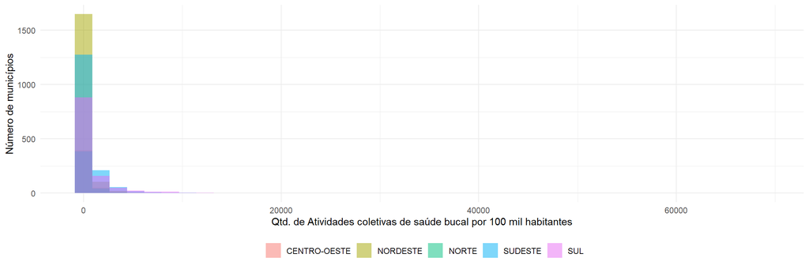

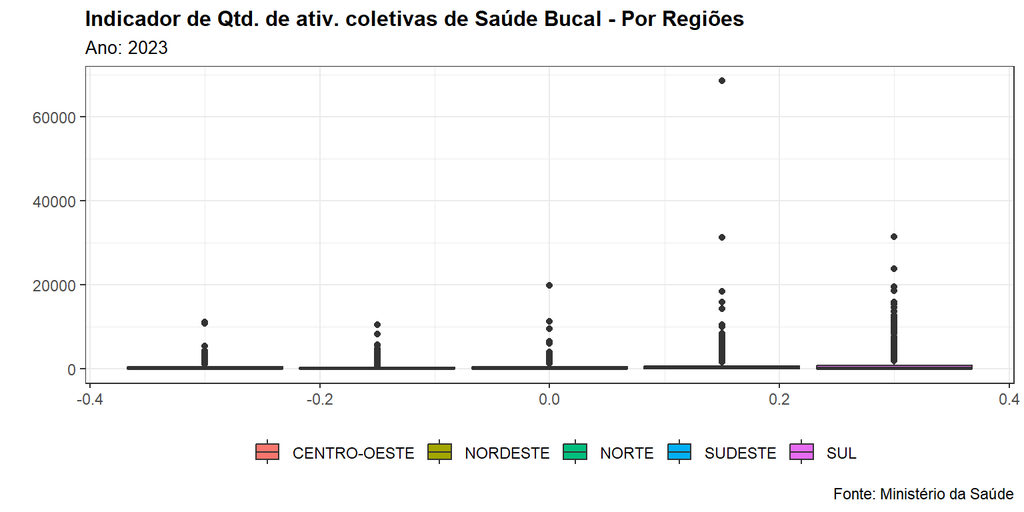

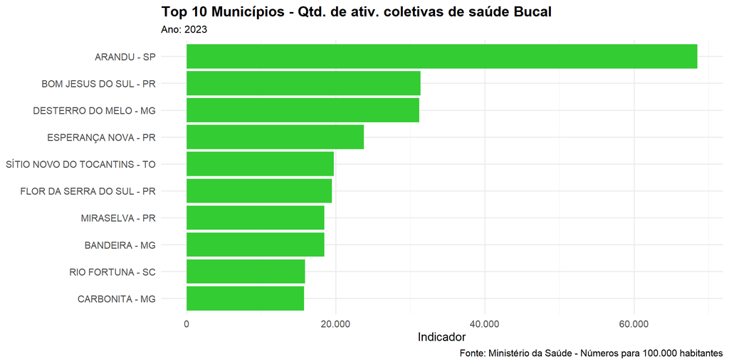

# 5.2 Indicadores de saúde mental

## Dados por UF

| UF | Regiao | Indicador | Media | Mediana | Desvio_pad | Minimo | Maximo | Pvalor_shapiro | Numerador | Denominador | n_municip |
| --- | --- | --- | --- | --- | --- | --- | --- | --- | --- | --- | --- |
| DISTRITO FEDERAL | CENTRO-OESTE | 331.54 | 331.54 | 331.54 | NA | 331.54 | 331.54 | NA | 6933 | 2091149 | 1 |
| GOIAS | CENTRO-OESTE | 157.30 | 295.87 | 58.01 | 1142.98 | 0.00 | 15820.15 | 0.00000 | 8333 | 5297680 | 239 |
| MATO GROSSO | CENTRO-OESTE | 142.17 | 168.89 | 41.76 | 411.23 | 0.00 | 3737.70 | 0.00000 | 4382 | 3082321 | 140 |
| MATO GROSSO DO SUL | CENTRO-OESTE | 139.59 | 110.21 | 51.27 | 169.63 | 0.00 | 1043.71 | 0.00000 | 3460 | 2478654 | 79 |
| ALAGOAS | NORDESTE | 182.83 | 236.21 | 109.97 | 480.73 | 0.00 | 4117.37 | 0.00000 | 4667 | 2552709 | 102 |
| BAHIA | NORDESTE | 99.44 | 149.01 | 41.33 | 554.77 | 0.00 | 9937.89 | 0.00000 | 12091 | 12158963 | 415 |
| CEARA | NORDESTE | 119.23 | 162.74 | 65.50 | 287.84 | 0.00 | 1876.04 | 0.00000 | 10446 | 8761012 | 184 |
| MARANHAO | NORDESTE | 90.72 | 96.76 | 57.33 | 145.68 | 0.00 | 1518.35 | 0.00000 | 5463 | 6022076 | 216 |
| PARAIBA | NORDESTE | 99.43 | 160.28 | 47.85 | 477.32 | 0.00 | 5807.94 | 0.00000 | 3754 | 3775421 | 219 |
| PERNAMBUCO | NORDESTE | 134.82 | 148.07 | 82.52 | 199.33 | 0.00 | 1590.82 | 0.00000 | 10158 | 7534514 | 185 |
| PIAUI | NORDESTE | 119.08 | 132.85 | 47.97 | 273.07 | 0.00 | 3172.76 | 0.00000 | 3793 | 3185217 | 215 |
| RIO GRANDE DO NORTE | NORDESTE | 113.41 | 199.64 | 76.34 | 370.87 | 0.00 | 3720.55 | 0.00000 | 3267 | 2880619 | 167 |
| SERGIPE | NORDESTE | 48.91 | 80.45 | 25.92 | 160.07 | 0.00 | 1161.70 | 0.00000 | 1074 | 2196034 | 75 |
| ACRE | NORTE | 106.22 | 180.60 | 52.29 | 387.86 | 0.00 | 1796.24 | 0.00000 | 733 | 690071 | 21 |
| AMAPA | NORTE | 183.28 | 114.44 | 68.38 | 109.21 | 5.83 | 326.82 | 0.01240 | 872 | 475774 | 16 |
| AMAZONAS | NORTE | 226.35 | 491.29 | 193.31 | 889.99 | 0.00 | 4660.65 | 0.00000 | 7181 | 3172538 | 62 |
| PARA | NORTE | 164.53 | 181.51 | 60.72 | 511.48 | 0.00 | 5473.52 | 0.00000 | 9441 | 5738072 | 141 |
| RONDONIA | NORTE | 144.33 | 100.77 | 30.89 | 178.06 | 0.00 | 769.69 | 0.00000 | 2044 | 1416214 | 52 |
| RORAIMA | NORTE | 74.91 | 80.70 | 70.34 | 87.05 | 0.00 | 283.15 | 0.01162 | 409 | 546019 | 15 |
| TOCANTINS | NORTE | 137.46 | 179.14 | 72.82 | 364.70 | 0.00 | 3045.18 | 0.00000 | 2053 | 1493485 | 136 |
| ESPIRITO SANTO | SUDESTE | 109.23 | 67.47 | 32.60 | 94.31 | 0.00 | 373.19 | 0.00000 | 2461 | 2253138 | 33 |
| MINAS GERAIS | SUDESTE | 284.22 | 473.56 | 174.35 | 998.40 | 0.00 | 13825.28 | 0.00000 | 54588 | 19206147 | 851 |
| RIO DE JANEIRO | SUDESTE | 145.44 | 130.92 | 60.18 | 204.95 | 0.00 | 1134.65 | 0.00000 | 16866 | 11596713 | 91 |
| SAO PAULO | SUDESTE | 334.24 | 208.36 | 24.80 | 654.37 | 0.00 | 7072.37 | 0.00000 | 99728 | 29837306 | 607 |
| PARANA | SUL | 96.82 | 203.01 | 24.71 | 1495.35 | 0.00 | 28637.41 | 0.00000 | 9816 | 10137924 | 382 |
| RIO GRANDE DO SUL | SUL | 377.25 | 951.03 | 395.85 | 1868.85 | 0.00 | 24147.89 | 0.00000 | 33667 | 8924305 | 491 |
| SANTA CATARINA | SUL | 152.34 | 223.73 | 53.91 | 531.34 | 0.00 | 6021.99 | 0.00000 | 10708 | 7029192 | 286 |

Note:  
*A coluna indicador foi calculada pela divisão do total de praticas adotadas (por UF, Regiao ou país) pela coluna de total de população cadastrada no IBGE.

## Dados por Regiao

| Regiao | Indicador | Media | Mediana | Desvio_pad | Min | Max | Pvalor_shapiro | Numerador | Denominador | n_municip |
| --- | --- | --- | --- | --- | --- | --- | --- | --- | --- | --- |
| CENTRO-OESTE | 178.44 | 225.26 | 53.46 | 860.80 | 0 | 15820.15 | 0 | 23108 | 12949804 | 459 |
| NORDESTE | 111.51 | 150.29 | 54.30 | 390.09 | 0 | 9937.89 | 0 | 54713 | 49066565 | 1778 |
| NORTE | 167.99 | 208.78 | 69.61 | 507.85 | 0 | 5473.52 | 0 | 22733 | 13532173 | 443 |
| SUDESTE | 276.09 | 343.62 | 87.51 | 850.25 | 0 | 13825.28 | 0 | 173643 | 62893304 | 1582 |
| SUL | 207.70 | 525.01 | 122.47 | 1554.55 | 0 | 28637.41 | 0 | 54191 | 26091421 | 1159 |

Note:  
*A coluna indicador foi calculada pela divisão do total de práticas adotadas (por UF, Regiao ou país) pela coluna de população cadastrada segundo o IBGE.

## Dados Nacionais

[output not shown]

Note:  
*A coluna indicador foi calculada pela divisão do total de práticas adotadas (por UF, Regiao ou país) pela população cadastrada segundo o IBGE.

## Gráficos

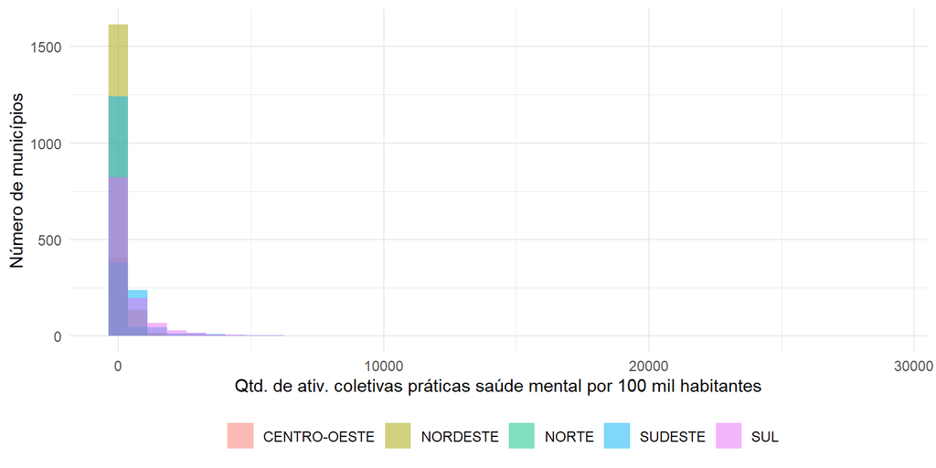

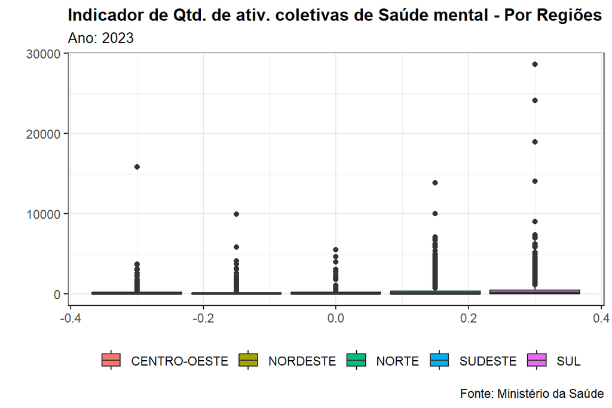

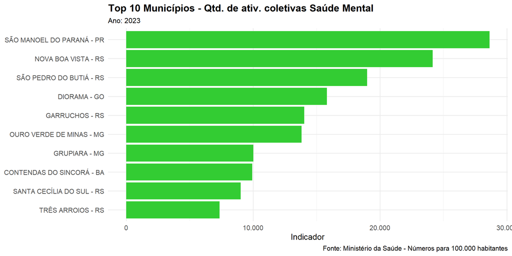

# 5.3 Indicadores de Qtd. de ativ. coletivas Alimentação saudável

## Dados por UF

| UF | Regiao | Indicador | Media | Mediana | Desvio_pad | Minimo | Maximo | Pvalor_shapiro | Numerador | Denominador | num_municip |
| --- | --- | --- | --- | --- | --- | --- | --- | --- | --- | --- | --- |
| DISTRITO FEDERAL | CENTRO-OESTE | 345.79 | 345.79 | 345.79 | NA | 345.79 | 345.79 | NA | 7231 | 2091149 | 1 |
| GOIAS | CENTRO-OESTE | 211.22 | 429.99 | 132.57 | 1295.22 | 0.00 | 17443.80 | 0.00000 | 11190 | 5297680 | 239 |
| MATO GROSSO | CENTRO-OESTE | 215.62 | 256.69 | 134.61 | 380.53 | 0.00 | 3037.82 | 0.00000 | 6646 | 3082321 | 140 |
| MATO GROSSO DO SUL | CENTRO-OESTE | 257.16 | 226.04 | 132.13 | 275.53 | 0.00 | 1640.62 | 0.00000 | 6374 | 2478654 | 79 |
| ALAGOAS | NORDESTE | 574.72 | 744.00 | 356.83 | 1083.07 | 0.00 | 6554.66 | 0.00000 | 14671 | 2552709 | 102 |
| BAHIA | NORDESTE | 270.89 | 357.65 | 160.17 | 695.88 | 0.00 | 9140.37 | 0.00000 | 32937 | 12158963 | 415 |
| CEARA | NORDESTE | 279.37 | 512.42 | 190.77 | 1137.68 | 0.00 | 12521.80 | 0.00000 | 24476 | 8761012 | 184 |
| MARANHAO | NORDESTE | 232.64 | 246.23 | 159.88 | 342.27 | 0.00 | 3795.89 | 0.00000 | 14010 | 6022076 | 216 |
| PARAIBA | NORDESTE | 201.67 | 272.45 | 149.74 | 422.89 | 0.00 | 2657.72 | 0.00000 | 7614 | 3775421 | 219 |
| PERNAMBUCO | NORDESTE | 331.33 | 445.74 | 268.84 | 606.74 | 0.00 | 4495.12 | 0.00000 | 24964 | 7534514 | 185 |
| PIAUI | NORDESTE | 344.72 | 441.29 | 220.47 | 801.75 | 0.00 | 6716.58 | 0.00000 | 10980 | 3185217 | 215 |
| RIO GRANDE DO NORTE | NORDESTE | 215.37 | 350.19 | 186.92 | 681.72 | 0.00 | 6484.32 | 0.00000 | 6204 | 2880619 | 167 |
| SERGIPE | NORDESTE | 116.35 | 218.16 | 110.11 | 465.68 | 0.00 | 3226.94 | 0.00000 | 2555 | 2196034 | 75 |
| ACRE | NORTE | 424.88 | 396.82 | 128.67 | 626.78 | 10.31 | 2217.23 | 0.00000 | 2932 | 690071 | 21 |
| AMAPA | NORTE | 212.29 | 227.99 | 173.72 | 230.81 | 17.79 | 913.19 | 0.00244 | 1010 | 475774 | 16 |
| AMAZONAS | NORTE | 637.79 | 1270.00 | 500.38 | 2629.65 | 0.00 | 15563.37 | 0.00000 | 20234 | 3172538 | 62 |
| PARA | NORTE | 402.09 | 503.92 | 230.83 | 933.59 | 0.00 | 7548.23 | 0.00000 | 23072 | 5738072 | 141 |
| RONDONIA | NORTE | 210.00 | 169.65 | 94.78 | 240.48 | 0.00 | 1144.94 | 0.00000 | 2974 | 1416214 | 52 |
| RORAIMA | NORTE | 77.10 | 94.05 | 71.46 | 117.46 | 0.00 | 435.10 | 0.00232 | 421 | 546019 | 15 |
| TOCANTINS | NORTE | 346.30 | 434.24 | 170.45 | 917.08 | 0.00 | 6132.08 | 0.00000 | 5172 | 1493485 | 136 |
| ESPIRITO SANTO | SUDESTE | 149.57 | 145.62 | 100.24 | 172.09 | 0.00 | 871.93 | 0.00000 | 3370 | 2253138 | 33 |
| MINAS GERAIS | SUDESTE | 487.01 | 879.61 | 494.13 | 1427.25 | 0.00 | 18189.42 | 0.00000 | 93535 | 19206147 | 851 |
| RIO DE JANEIRO | SUDESTE | 385.85 | 228.74 | 135.36 | 256.30 | 0.00 | 1145.31 | 0.00000 | 44746 | 11596713 | 91 |
| SAO PAULO | SUDESTE | 270.25 | 209.37 | 49.41 | 551.55 | 0.00 | 8022.56 | 0.00000 | 80636 | 29837306 | 607 |
| PARANA | SUL | 117.55 | 206.05 | 62.38 | 428.14 | 0.00 | 5923.93 | 0.00000 | 11917 | 10137924 | 382 |
| RIO GRANDE DO SUL | SUL | 333.22 | 620.04 | 353.46 | 839.94 | 0.00 | 8874.08 | 0.00000 | 29738 | 8924305 | 491 |
| SANTA CATARINA | SUL | 137.46 | 289.61 | 96.65 | 584.25 | 0.00 | 6513.16 | 0.00000 | 9662 | 7029192 | 286 |

Note:  
*A coluna indicador foi calculada pela divisão do total de praticas adotadas (por UF, Regiao ou país) pela coluna de total de população cadastrada no IBGE.

## Dados por Região

| Regiao | Indicador | Media | Mediana | Desvio_pad | Min | Max | Pvalor_shapiro | Numerador | Denominador | num_municip |
| --- | --- | --- | --- | --- | --- | --- | --- | --- | --- | --- |
| CENTRO-OESTE | 242.79 | 341.85 | 132.57 | 968.10 | 0 | 17443.80 | 0 | 31441 | 12949804 | 459 |
| NORDESTE | 282.09 | 384.50 | 178.16 | 729.44 | 0 | 12521.80 | 0 | 138411 | 49066565 | 1778 |
| NORTE | 412.46 | 521.59 | 188.06 | 1272.65 | 0 | 15563.37 | 0 | 55815 | 13532173 | 443 |
| SUDESTE | 353.44 | 569.69 | 241.64 | 1152.44 | 0 | 18189.42 | 0 | 222287 | 62893304 | 1582 |
| SUL | 196.68 | 402.05 | 175.13 | 691.95 | 0 | 8874.08 | 0 | 51317 | 26091421 | 1159 |

Note:  
*A coluna indicador foi calculada pela divisão do total de práticas adotadas (por UF, Regiao ou país) pela coluna de população cadastrada segundo o IBGE.

## Dados Nacionais

| Pais | Indicador | Media | Mediana | Desvio_pad | Min | Max | Pvalor_shapiro | Numerador | Denominador | num_municip |
| --- | --- | --- | --- | --- | --- | --- | --- | --- | --- | --- |
| Brasil | 303.45 | 449.89 | 188.06 | 939.64 | 0 | 18189.42 | NA | 499271 | 164533267 | 5421 |

Note:  
*A coluna indicador foi calculada pela divisão do total de práticas adotadas (por UF, Regiao ou país) pela população cadastrada segundo o IBGE.

## Gráficos

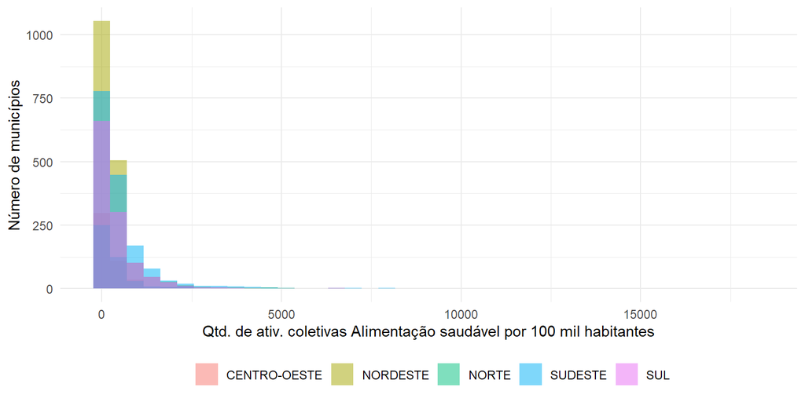

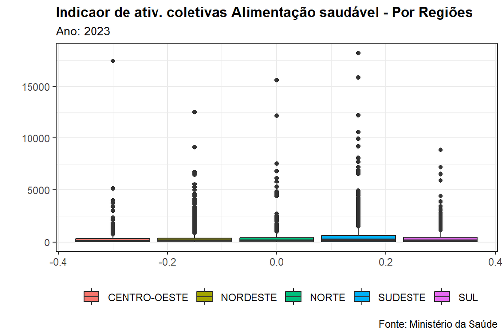

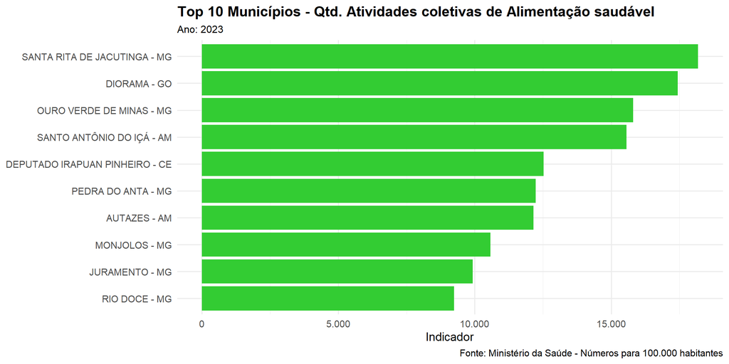

# 5.4 Indicadores de quantitativo de atividades coletivas de saúde sexual e reprodutiva (SSR)

## Dados por UF

| UF | Regiao | Indicador | Media | Mediana | Desvio_pad | Min | Max | Pvalor_shapiro | Numerador | Denominador | num_municip |
| --- | --- | --- | --- | --- | --- | --- | --- | --- | --- | --- | --- |
| DISTRITO FEDERAL | CENTRO-OESTE | 74.22 | 74.22 | 74.22 | NA | 74.22 | 74.22 | NA | 1552 | 2091149 | 1 |
| GOIAS | CENTRO-OESTE | 63.86 | 102.70 | 34.03 | 474.17 | 0.00 | 7171.85 | 0.00000 | 3383 | 5297680 | 239 |
| MATO GROSSO | CENTRO-OESTE | 94.31 | 93.61 | 52.11 | 123.28 | 0.00 | 826.77 | 0.00000 | 2907 | 3082321 | 140 |
| MATO GROSSO DO SUL | CENTRO-OESTE | 82.99 | 72.91 | 50.70 | 77.80 | 0.00 | 373.60 | 0.00000 | 2057 | 2478654 | 79 |
| ALAGOAS | NORDESTE | 176.09 | 215.89 | 103.60 | 342.32 | 0.00 | 2721.25 | 0.00000 | 4495 | 2552709 | 102 |
| BAHIA | NORDESTE | 103.46 | 127.19 | 70.48 | 237.14 | 0.00 | 3082.19 | 0.00000 | 12580 | 12158963 | 415 |
| CEARA | NORDESTE | 81.53 | 141.03 | 76.20 | 205.68 | 0.00 | 1472.93 | 0.00000 | 7143 | 8761012 | 184 |
| MARANHAO | NORDESTE | 107.21 | 107.61 | 89.86 | 97.42 | 0.00 | 638.62 | 0.00000 | 6456 | 6022076 | 216 |
| PARAIBA | NORDESTE | 66.40 | 95.06 | 64.51 | 120.80 | 0.00 | 943.00 | 0.00000 | 2507 | 3775421 | 219 |
| PERNAMBUCO | NORDESTE | 103.01 | 131.75 | 88.35 | 160.11 | 0.00 | 1296.57 | 0.00000 | 7761 | 7534514 | 185 |
| PIAUI | NORDESTE | 94.75 | 111.21 | 53.44 | 151.05 | 0.00 | 1035.44 | 0.00000 | 3018 | 3185217 | 215 |
| RIO GRANDE DO NORTE | NORDESTE | 84.01 | 111.19 | 73.38 | 117.32 | 0.00 | 551.16 | 0.00000 | 2420 | 2880619 | 167 |
| SERGIPE | NORDESTE | 39.30 | 63.66 | 35.61 | 67.87 | 0.00 | 320.46 | 0.00000 | 863 | 2196034 | 75 |
| ACRE | NORTE | 123.47 | 142.98 | 62.03 | 159.91 | 0.00 | 561.32 | 0.00054 | 852 | 690071 | 21 |
| AMAPA | NORTE | 66.00 | 69.86 | 41.59 | 65.38 | 0.00 | 196.68 | 0.01107 | 314 | 475774 | 16 |
| AMAZONAS | NORTE | 264.99 | 533.57 | 243.27 | 1050.63 | 0.00 | 6400.00 | 0.00000 | 8407 | 3172538 | 62 |
| PARA | NORTE | 160.54 | 178.16 | 98.74 | 255.93 | 0.00 | 2172.69 | 0.00000 | 9212 | 5738072 | 141 |
| RONDONIA | NORTE | 122.44 | 96.87 | 68.35 | 109.58 | 0.00 | 624.51 | 0.00000 | 1734 | 1416214 | 52 |
| RORAIMA | NORTE | 92.85 | 104.80 | 83.74 | 116.58 | 0.00 | 362.18 | 0.01528 | 507 | 546019 | 15 |
| TOCANTINS | NORTE | 125.61 | 162.30 | 80.89 | 279.00 | 0.00 | 2242.05 | 0.00000 | 1876 | 1493485 | 136 |
| ESPIRITO SANTO | SUDESTE | 38.57 | 60.16 | 25.41 | 100.31 | 0.00 | 493.78 | 0.00000 | 869 | 2253138 | 33 |
| MINAS GERAIS | SUDESTE | 158.68 | 240.33 | 165.68 | 279.57 | 0.00 | 3476.00 | 0.00000 | 30477 | 19206147 | 851 |
| RIO DE JANEIRO | SUDESTE | 169.61 | 112.54 | 69.85 | 131.24 | 0.00 | 701.48 | 0.00000 | 19669 | 11596713 | 91 |
| SAO PAULO | SUDESTE | 72.12 | 65.57 | 24.82 | 111.19 | 0.00 | 894.92 | 0.00000 | 21519 | 29837306 | 607 |
| PARANA | SUL | 26.54 | 42.79 | 17.01 | 74.18 | 0.00 | 609.55 | 0.00000 | 2691 | 10137924 | 382 |
| RIO GRANDE DO SUL | SUL | 72.88 | 128.94 | 60.94 | 183.74 | 0.00 | 1877.93 | 0.00000 | 6504 | 8924305 | 491 |
| SANTA CATARINA | SUL | 29.15 | 75.65 | 28.39 | 131.79 | 0.00 | 715.27 | 0.00000 | 2049 | 7029192 | 286 |

Note:  
*A coluna indicador foi calculada pela divisão do total de praticas adotadas (por UF, Regiao ou país) pela coluna de total de população cadastrada no IBGE.

## Dados por Regiao

| Regiao | Indicador | Media | Mediana | Desvio_pad | Min | Max | Pvalor_shapiro | Numerador | Denominador | num_municip |
| --- | --- | --- | --- | --- | --- | --- | --- | --- | --- | --- |
| CENTRO-OESTE | 76.44 | 94.74 | 41.43 | 350.13 | 0 | 7171.85 | 0 | 9899 | 12949804 | 459 |
| NORDESTE | 96.28 | 121.73 | 74.02 | 186.49 | 0 | 3082.19 | 0 | 47243 | 49066565 | 1778 |
| NORTE | 169.24 | 205.43 | 91.91 | 467.41 | 0 | 6400.00 | 0 | 22902 | 13532173 | 443 |
| SUDESTE | 115.33 | 162.17 | 95.41 | 234.89 | 0 | 3476.00 | 0 | 72534 | 62893304 | 1582 |
| SUL | 43.09 | 87.40 | 36.15 | 147.63 | 0 | 1877.93 | 0 | 11244 | 26091421 | 1159 |

Note:  
*A coluna indicador foi calculada pela divisão do total de práticas adotadas (por UF, Regiao ou país) pela coluna de população cadastrada segundo o IBGE.

## Dados Nacionais

| Pais | Indicador | Media | Mediana | Desvio_pad | Min | Max | pvalor_shapiro | Numerador | Denominador | num_municip |
| --- | --- | --- | --- | --- | --- | --- | --- | --- | --- | --- |
| Brasil | 99.57 | 130.75 | 66.24 | 248.22 | 0 | 7171.85 | NA | 163822 | 164533267 | 5421 |

Note:  
*A coluna indicador foi calculada pela divisão do total de práticas adotadas (por UF, Regiao ou país) pela população cadastrada segundo o IBGE.

## Gráficos

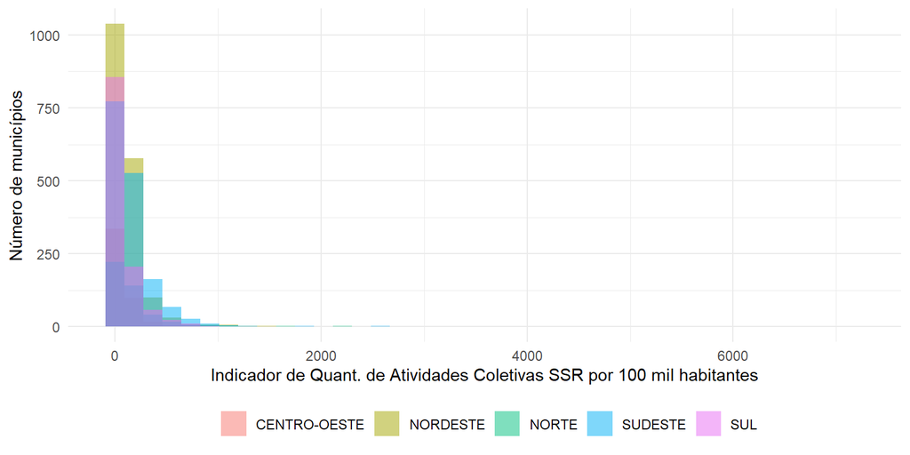

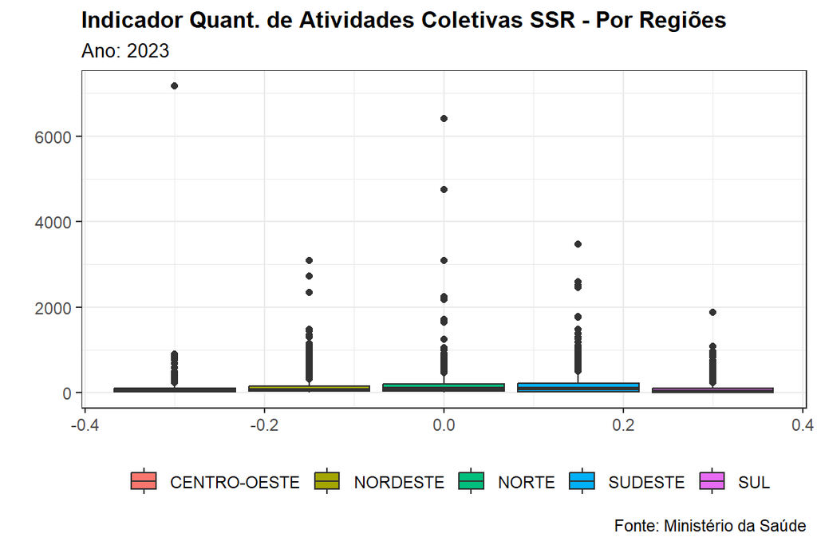

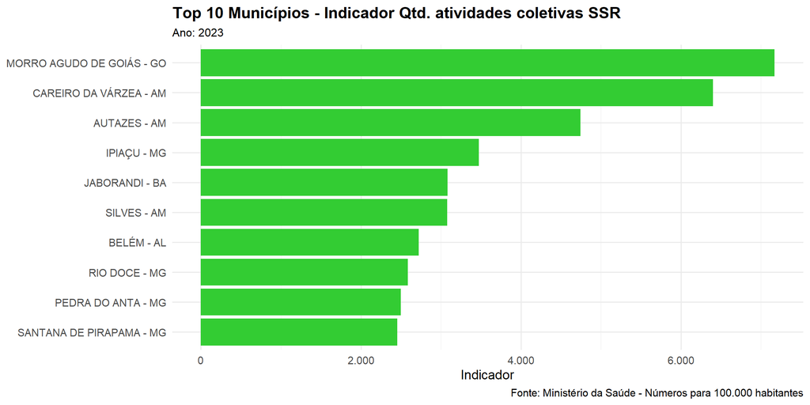

# 5.5 Indicadores de práticas autocuidado

## Dados por UF

| UF | Regiao | Indicador | Media | Mediana | Desvio_pad | Min | Max | Pvalor_shapiro | Numerador | Denominador | num_municip |
| --- | --- | --- | --- | --- | --- | --- | --- | --- | --- | --- | --- |
| DISTRITO FEDERAL | CENTRO-OESTE | 445.35 | 445.35 | 445.35 | NA | 445.35 | 445.35 | NA | 9313 | 2091149 | 1 |
| GOIAS | CENTRO-OESTE | 226.23 | 452.98 | 75.10 | 1357.92 | 0.00 | 13696.92 | 0.00000 | 11985 | 5297680 | 239 |
| MATO GROSSO | CENTRO-OESTE | 137.56 | 195.88 | 36.08 | 860.97 | 0.00 | 9770.49 | 0.00000 | 4240 | 3082321 | 140 |
| MATO GROSSO DO SUL | CENTRO-OESTE | 271.44 | 161.66 | 65.27 | 252.38 | 0.00 | 1500.33 | 0.00000 | 6728 | 2478654 | 79 |
| ALAGOAS | NORDESTE | 335.68 | 392.18 | 57.60 | 918.70 | 0.00 | 6507.34 | 0.00000 | 8569 | 2552709 | 102 |
| BAHIA | NORDESTE | 172.48 | 208.03 | 39.06 | 591.69 | 0.00 | 5022.46 | 0.00000 | 20972 | 12158963 | 415 |
| CEARA | NORDESTE | 217.75 | 353.43 | 35.84 | 1071.70 | 0.00 | 11737.14 | 0.00000 | 19077 | 8761012 | 184 |
| MARANHAO | NORDESTE | 141.93 | 151.89 | 28.85 | 478.71 | 0.00 | 4939.16 | 0.00000 | 8547 | 6022076 | 216 |
| PARAIBA | NORDESTE | 256.05 | 327.74 | 50.03 | 962.84 | 0.00 | 7504.90 | 0.00000 | 9667 | 3775421 | 219 |
| PERNAMBUCO | NORDESTE | 221.13 | 282.86 | 98.48 | 604.45 | 0.00 | 5081.94 | 0.00000 | 16661 | 7534514 | 185 |
| PIAUI | NORDESTE | 351.12 | 349.85 | 46.45 | 1187.68 | 0.00 | 12833.75 | 0.00000 | 11184 | 3185217 | 215 |
| RIO GRANDE DO NORTE | NORDESTE | 201.14 | 276.06 | 56.32 | 917.89 | 0.00 | 7405.47 | 0.00000 | 5794 | 2880619 | 167 |
| SERGIPE | NORDESTE | 92.99 | 300.50 | 20.54 | 1316.95 | 0.00 | 8818.39 | 0.00000 | 2042 | 2196034 | 75 |
| ACRE | NORTE | 148.83 | 179.23 | 27.14 | 315.26 | 0.00 | 1234.91 | 0.00001 | 1027 | 690071 | 21 |
| AMAPA | NORTE | 139.14 | 67.41 | 30.50 | 82.03 | 0.00 | 257.54 | 0.00122 | 662 | 475774 | 16 |
| AMAZONAS | NORTE | 220.83 | 363.29 | 81.06 | 728.37 | 0.00 | 4327.75 | 0.00000 | 7006 | 3172538 | 62 |
| PARA | NORTE | 271.62 | 349.41 | 50.11 | 871.89 | 0.00 | 7231.63 | 0.00000 | 15586 | 5738072 | 141 |
| RONDONIA | NORTE | 76.82 | 65.76 | 30.18 | 90.46 | 0.00 | 390.32 | 0.00000 | 1088 | 1416214 | 52 |
| RORAIMA | NORTE | 120.33 | 170.07 | 25.01 | 379.87 | 0.00 | 1472.56 | 0.00000 | 657 | 546019 | 15 |
| TOCANTINS | NORTE | 267.23 | 404.03 | 74.19 | 1061.25 | 0.00 | 7540.44 | 0.00000 | 3991 | 1493485 | 136 |
| ESPIRITO SANTO | SUDESTE | 74.25 | 55.54 | 26.38 | 74.04 | 0.00 | 347.48 | 0.00000 | 1673 | 2253138 | 33 |
| MINAS GERAIS | SUDESTE | 550.30 | 788.03 | 230.73 | 1637.97 | 0.00 | 21790.54 | 0.00000 | 105692 | 19206147 | 851 |
| RIO DE JANEIRO | SUDESTE | 254.67 | 152.01 | 43.59 | 312.70 | 0.00 | 2382.60 | 0.00000 | 29533 | 11596713 | 91 |
| SAO PAULO | SUDESTE | 449.01 | 336.84 | 36.76 | 1122.32 | 0.00 | 12689.70 | 0.00000 | 133972 | 29837306 | 607 |
| PARANA | SUL | 126.09 | 166.77 | 20.87 | 540.06 | 0.00 | 7221.32 | 0.00000 | 12783 | 10137924 | 382 |
| RIO GRANDE DO SUL | SUL | 269.15 | 471.50 | 158.23 | 1418.11 | 0.00 | 22307.96 | 0.00000 | 24020 | 8924305 | 491 |
| SANTA CATARINA | SUL | 183.26 | 299.41 | 40.03 | 1215.82 | 0.00 | 17855.56 | 0.00000 | 12882 | 7029192 | 286 |

Note:  
*A coluna indicador foi calculada pela divisão do total de praticas adotadas (por UF, Regiao ou país) pela coluna de total de população cadastrada no IBGE.

## Dados por Regiao

| Regiao | Indicador | Media | Mediana | Desvio_padrao | Minimo | Maximo | Pvalor_shapiro | Numerador | Denominador | num_municip |
| --- | --- | --- | --- | --- | --- | --- | --- | --- | --- | --- |
| CENTRO-OESTE | 249.16 | 324.41 | 52.46 | 1101.04 | 0 | 13696.92 | 0 | 32266 | 12949804 | 459 |
| NORDESTE | 208.93 | 276.79 | 43.46 | 867.91 | 0 | 12833.75 | 0 | 102513 | 49066565 | 1778 |
| NORTE | 221.82 | 310.50 | 52.35 | 826.12 | 0 | 7540.44 | 0 | 30017 | 13532173 | 443 |
| SUDESTE | 430.68 | 563.05 | 115.07 | 1411.71 | 0 | 21790.54 | 0 | 270870 | 62893304 | 1582 |
| SUL | 190.43 | 328.60 | 72.02 | 1152.49 | 0 | 22307.96 | 0 | 49685 | 26091421 | 1159 |

Note:  
*A coluna indicador foi calculada pela divisão do total de práticas adotadas (por UF, Regiao ou país) pela coluna de população cadastrada segundo o IBGE.

## Dados Nacionais

[output not shown]

Note:  
*A coluna indicador foi calculada pela divisão do total de práticas adotadas (por UF, Regiao ou país) pela população cadastrada segundo o IBGE.

## Gráficos

[figure not shown]

[figure not shown]

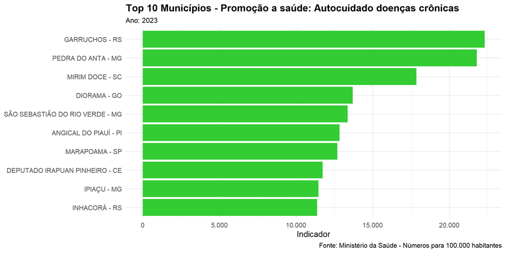

# 5.6 Indicadores de atividades coletivas de Antropometria

## Dados por UF

| UF | Regiao | Indicador | Media | Mediana | Desvio_pad | Min | Max | Pvalor_shapiro | Numerador | Denominador | num_municip |
| --- | --- | --- | --- | --- | --- | --- | --- | --- | --- | --- | --- |
| DISTRITO FEDERAL | CENTRO-OESTE | 92.10 | 92.10 | 92.10 | NA | 92.1 | 92.10 | NA | 1926 | 2091149 | 1 |
| GOIAS | CENTRO-OESTE | 150.00 | 252.70 | 61.12 | 488.77 | 0.0 | 5100.05 | 0.00000 | 7928 | 5285178 | 231 |
| MATO GROSSO | CENTRO-OESTE | 130.90 | 169.73 | 97.78 | 217.98 | 0.0 | 1400.02 | 0.00000 | 4021 | 3071752 | 138 |
| MATO GROSSO DO SUL | CENTRO-OESTE | 167.92 | 185.46 | 86.98 | 290.38 | 0.0 | 2031.25 | 0.00000 | 4153 | 2473265 | 78 |
| ALAGOAS | NORDESTE | 195.44 | 256.31 | 125.87 | 328.79 | 0.0 | 1869.26 | 0.00000 | 4989 | 2552709 | 102 |
| BAHIA | NORDESTE | 128.48 | 175.51 | 55.03 | 396.25 | 0.0 | 5283.76 | 0.00000 | 15267 | 11882677 | 397 |
| CEARA | NORDESTE | 137.76 | 225.11 | 99.72 | 346.87 | 0.0 | 2770.23 | 0.00000 | 12041 | 8740685 | 182 |
| MARANHAO | NORDESTE | 166.55 | 197.24 | 98.79 | 268.15 | 0.0 | 1844.58 | 0.00000 | 9955 | 5977174 | 209 |
| PARAIBA | NORDESTE | 253.34 | 320.24 | 90.60 | 653.77 | 0.0 | 5073.83 | 0.00000 | 9433 | 3723470 | 212 |
| PERNAMBUCO | NORDESTE | 167.07 | 235.43 | 61.84 | 468.76 | 0.0 | 3350.56 | 0.00000 | 12588 | 7534514 | 185 |
| PIAUI | NORDESTE | 166.99 | 243.10 | 91.06 | 460.75 | 0.0 | 4787.62 | 0.00000 | 5237 | 3136094 | 207 |
| RIO GRANDE DO NORTE | NORDESTE | 139.47 | 225.25 | 104.89 | 453.44 | 0.0 | 4177.08 | 0.00000 | 4011 | 2875806 | 166 |
| SERGIPE | NORDESTE | 96.08 | 174.68 | 55.76 | 326.09 | 0.0 | 2135.96 | 0.00000 | 2101 | 2186702 | 73 |
| ACRE | NORTE | 208.67 | 353.70 | 71.51 | 679.09 | 0.0 | 3017.24 | 0.00000 | 1440 | 690071 | 21 |
| AMAPA | NORTE | 225.74 | 193.31 | 125.40 | 253.83 | 0.0 | 813.82 | 0.00012 | 1074 | 475774 | 16 |
| AMAZONAS | NORTE | 360.72 | 780.11 | 308.11 | 2216.90 | 0.0 | 16794.58 | 0.00000 | 11363 | 3150059 | 60 |
| PARA | NORTE | 286.01 | 337.44 | 118.45 | 649.57 | 0.0 | 5265.66 | 0.00000 | 16334 | 5711063 | 138 |
| RONDONIA | NORTE | 217.69 | 172.97 | 89.66 | 220.33 | 0.0 | 1112.03 | 0.00000 | 3083 | 1416214 | 52 |
| RORAIMA | NORTE | 28.20 | 58.15 | 15.09 | 92.08 | 0.0 | 298.49 | 0.00073 | 143 | 507119 | 12 |
| TOCANTINS | NORTE | 165.08 | 309.33 | 70.42 | 738.98 | 0.0 | 6856.19 | 0.00000 | 2387 | 1445992 | 126 |
| ESPIRITO SANTO | SUDESTE | 110.09 | 73.04 | 20.47 | 114.85 | 0.0 | 441.25 | 0.00000 | 2449 | 2224465 | 31 |
| MINAS GERAIS | SUDESTE | 163.24 | 319.07 | 93.40 | 933.66 | 0.0 | 18168.51 | 0.00000 | 31302 | 19175304 | 844 |
| RIO DE JANEIRO | SUDESTE | 117.13 | 117.76 | 45.21 | 244.83 | 0.0 | 1852.49 | 0.00000 | 13471 | 11501317 | 87 |
| SAO PAULO | SUDESTE | 97.61 | 140.08 | 22.62 | 319.63 | 0.0 | 2937.00 | 0.00000 | 28555 | 29253025 | 553 |
| PARANA | SUL | 125.70 | 221.54 | 48.06 | 377.43 | 0.0 | 2282.55 | 0.00000 | 12517 | 9957845 | 364 |
| RIO GRANDE DO SUL | SUL | 183.71 | 307.60 | 115.78 | 599.73 | 0.0 | 7661.59 | 0.00000 | 16262 | 8852111 | 478 |
| SANTA CATARINA | SUL | 80.70 | 220.87 | 33.83 | 599.41 | 0.0 | 8289.47 | 0.00000 | 5546 | 6872446 | 269 |

Note:  
*A coluna indicador foi calculada pela divisão do total de praticas adotadas (por UF, Regiao ou país) pela coluna de total de população cadastrada no IBGE.

## Dados por Regiao

| Regiao | indicador | Media | Mediana | Desvio_pad | Minimo | Maximo | Pvalor_shapiro | Numerador | Denominador | num_municip |
| --- | --- | --- | --- | --- | --- | --- | --- | --- | --- | --- |
| CENTRO-OESTE | 139.52 | 215.08 | 82.63 | 391.87 | 0 | 5100.05 | 0 | 18028 | 12921344 | 448 |
| NORDESTE | 155.57 | 225.00 | 80.92 | 435.96 | 0 | 5283.76 | 0 | 75622 | 48609831 | 1733 |
| NORTE | 267.42 | 358.97 | 114.06 | 1022.31 | 0 | 16794.58 | 0 | 35824 | 13396292 | 425 |
| SUDESTE | 121.92 | 237.14 | 56.18 | 731.33 | 0 | 18168.51 | 0 | 75777 | 62154111 | 1515 |
| SUL | 133.65 | 258.41 | 71.86 | 538.26 | 0 | 8289.47 | 0 | 34325 | 25682402 | 1111 |

Note:  
*A coluna indicador foi calculada pela divisão do total de práticas adotadas (por UF, Regiao ou país) pela coluna de população cadastrada segundo o IBGE.

## Dados Nacionais

| Pais | Indicador | Media | Mediana | Desvio_pad | Min | Max | Pvalor_shapiro | Numerador | Denominador | num_municip |
| --- | --- | --- | --- | --- | --- | --- | --- | --- | --- | --- |
| Brasil | 147.19 | 245.64 | 72.08 | 615.11 | 0 | 18168.51 | NA | 239576 | 162763980 | 5232 |

Note:  
*A coluna indicador foi calculada pela divisão do total de práticas adotadas (por UF, Regiao ou país) pela população cadastrada segundo o IBGE.

## Gráficos

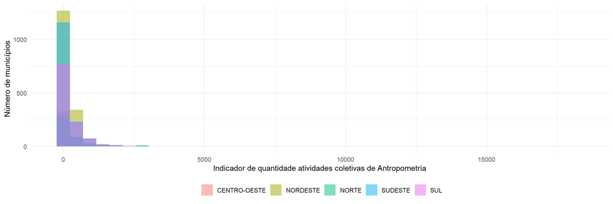

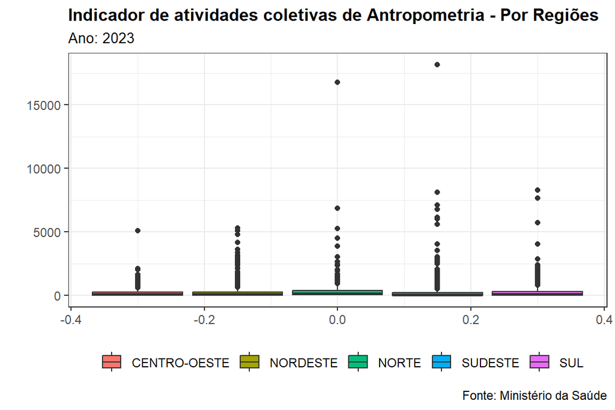

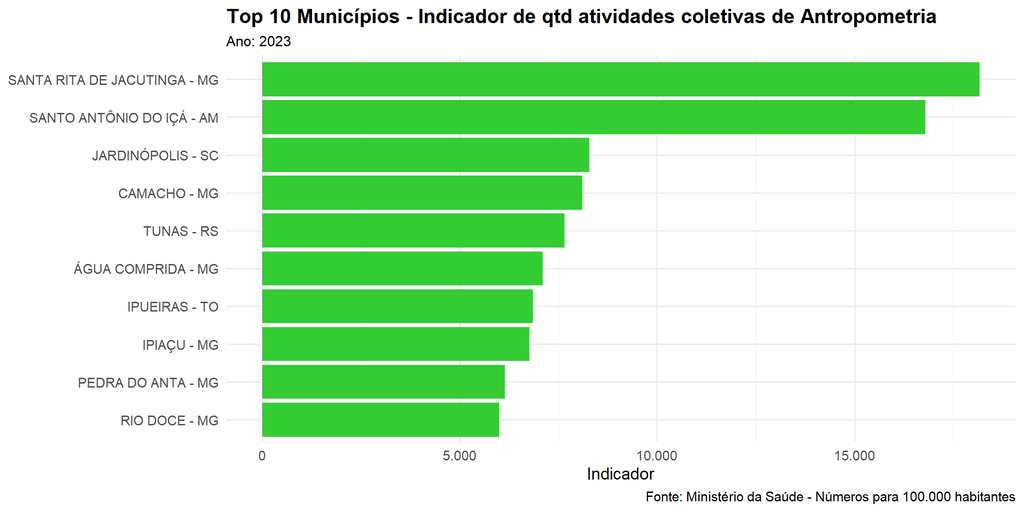

# 5.7 Indicadores de Práticas de atividades corporais

## Dados por UF

| UF | Regiao | Indicador | Media | Mediana | Desvio_pad | Min | Max | Pvalor_shapiro | Numerador | Denominador | num_municip |
| --- | --- | --- | --- | --- | --- | --- | --- | --- | --- | --- | --- |
| DISTRITO FEDERAL | CENTRO-OESTE | 193.15 | 4039.00 | 4039.0 | NA | 4039 | 4039 | NA | 4039 | 2091149 | 1 |
| GOIAS | CENTRO-OESTE | 742.78 | 169.94 | 53.0 | 270.84 | 0 | 1789 | 0.00000 | 39257 | 5285178 | 231 |
| MATO GROSSO | CENTRO-OESTE | 292.31 | 65.07 | 3.0 | 176.49 | 0 | 1478 | 0.00000 | 8979 | 3071752 | 138 |
| MATO GROSSO DO SUL | CENTRO-OESTE | 300.01 | 95.13 | 1.0 | 390.97 | 0 | 2511 | 0.00000 | 7420 | 2473265 | 78 |
| ALAGOAS | NORDESTE | 911.07 | 228.01 | 56.5 | 329.31 | 0 | 1885 | 0.00000 | 23257 | 2552709 | 102 |
| BAHIA | NORDESTE | 443.06 | 132.61 | 9.0 | 293.48 | 0 | 2382 | 0.00000 | 52647 | 11882677 | 397 |
| CEARA | NORDESTE | 694.38 | 333.48 | 110.5 | 550.85 | 0 | 3134 | 0.00000 | 60694 | 8740685 | 182 |
| MARANHAO | NORDESTE | 401.88 | 114.93 | 16.0 | 300.83 | 0 | 2253 | 0.00000 | 24021 | 5977174 | 209 |
| PARAIBA | NORDESTE | 769.58 | 135.17 | 5.0 | 274.76 | 0 | 1887 | 0.00000 | 28655 | 3723470 | 212 |
| PERNAMBUCO | NORDESTE | 671.82 | 273.61 | 12.0 | 786.33 | 0 | 6410 | 0.00000 | 50618 | 7534514 | 185 |
| PIAUI | NORDESTE | 1203.03 | 182.26 | 15.0 | 431.99 | 0 | 4208 | 0.00000 | 37728 | 3136094 | 207 |
| RIO GRANDE DO NORTE | NORDESTE | 572.12 | 99.11 | 11.5 | 211.53 | 0 | 1518 | 0.00000 | 16453 | 2875806 | 166 |
| SERGIPE | NORDESTE | 304.25 | 91.14 | 2.0 | 245.01 | 0 | 1866 | 0.00000 | 6653 | 2186702 | 73 |
| ACRE | NORTE | 536.90 | 176.43 | 21.0 | 585.51 | 0 | 2716 | 0.00000 | 3705 | 690071 | 21 |
| AMAPA | NORTE | 288.37 | 85.75 | 19.0 | 268.58 | 0 | 1091 | 0.00000 | 1372 | 475774 | 16 |
| AMAZONAS | NORTE | 865.25 | 454.27 | 102.5 | 1087.17 | 0 | 7431 | 0.00000 | 27256 | 3150059 | 60 |
| PARA | NORTE | 726.50 | 300.66 | 65.0 | 463.91 | 0 | 1899 | 0.00000 | 41491 | 5711063 | 138 |
| RONDONIA | NORTE | 79.44 | 21.63 | 0.0 | 100.01 | 0 | 718 | 0.00000 | 1125 | 1416214 | 52 |
| RORAIMA | NORTE | 177.08 | 74.83 | 19.0 | 154.84 | 0 | 549 | 0.00003 | 898 | 507119 | 12 |
| TOCANTINS | NORTE | 580.78 | 66.65 | 10.0 | 129.24 | 0 | 796 | 0.00000 | 8398 | 1445992 | 126 |
| ESPIRITO SANTO | SUDESTE | 201.17 | 144.35 | 3.0 | 583.35 | 0 | 3230 | 0.00000 | 4475 | 2224465 | 31 |
| MINAS GERAIS | SUDESTE | 1469.74 | 333.92 | 170.0 | 590.86 | 0 | 7071 | 0.00000 | 281828 | 19175304 | 844 |
| RIO DE JANEIRO | SUDESTE | 261.86 | 346.17 | 16.0 | 1385.94 | 0 | 12394 | 0.00000 | 30117 | 11501317 | 87 |
| SAO PAULO | SUDESTE | 492.10 | 260.31 | 4.0 | 2588.12 | 0 | 59161 | 0.00000 | 143953 | 29253025 | 553 |
| PARANA | SUL | 245.75 | 67.23 | 1.0 | 200.19 | 0 | 2315 | 0.00000 | 24471 | 9957845 | 364 |
| RIO GRANDE DO SUL | SUL | 586.15 | 108.55 | 16.0 | 332.01 | 0 | 5755 | 0.00000 | 51887 | 8852111 | 478 |
| SANTA CATARINA | SUL | 389.40 | 99.48 | 3.0 | 235.21 | 0 | 2481 | 0.00000 | 26761 | 6872446 | 269 |

Note:  
*A coluna indicador foi calculada pela divisão do total de praticas adotadas (por UF, Regiao ou país) pela coluna de total de população cadastrada no IBGE.

## Dados por Regiao

| Regiao | indicador | Media | Mediana | Desvio_pad | Minimo | Maximo | Pvalor_shapiro | Numerador | Denominador | num_municip |
| --- | --- | --- | --- | --- | --- | --- | --- | --- | --- | --- |
| CENTRO-OESTE | 461.99 | 1397.47 | 90.11 | 3724.40 | 0 | 50341.21 | 0 | 626068.5 | 12921344 | 448 |
| NORDESTE | 618.65 | 1005.29 | 96.37 | 2039.60 | 0 | 18513.33 | 0 | 1742161.1 | 48609831 | 1733 |
| NORTE | 628.87 | 1013.54 | 166.34 | 2029.74 | 0 | 16783.84 | 0 | 430753.4 | 13396292 | 425 |
| SUDESTE | 740.70 | 1863.62 | 536.81 | 3252.63 | 0 | 41049.56 | 0 | 2823380.3 | 62154111 | 1515 |
| SUL | 401.52 | 1111.65 | 69.71 | 3394.57 | 0 | 36733.56 | 0 | 1235044.5 | 25682402 | 1111 |

Note:  
*A coluna indicador foi calculada pela divisão do total de práticas adotadas (por UF, Regiao ou país) pela coluna de população cadastrada segundo o IBGE.

## Dados Nacionais

| Pais | Indicador | Media | Mediana | Desvio_pad | Min | Max | Pvalor_shapiro | Numerador | Denominador | num_municip |
| --- | --- | --- | --- | --- | --- | --- | --- | --- | --- | --- |
| Brasil | 619.4 | 1310.67 | 144.74 | 2922.24 | 0 | 50341.21 | NA | 1008158 | 162763980 | 5232 |

Note:  
*A coluna indicador foi calculada pela divisão do total de práticas adotadas (por UF, Regiao ou país) pela população cadastrada segundo o IBGE.

## Gráficos

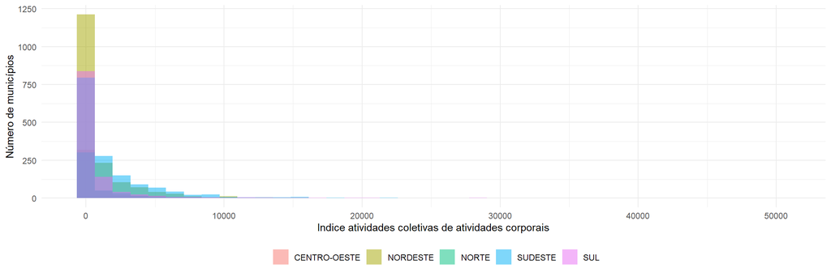

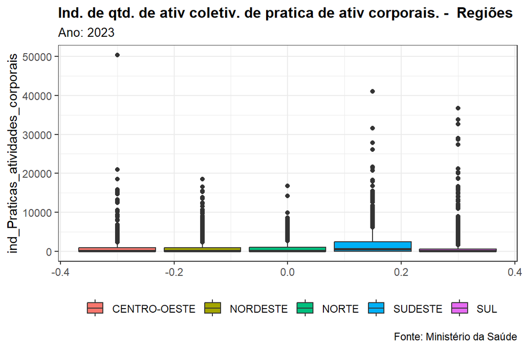

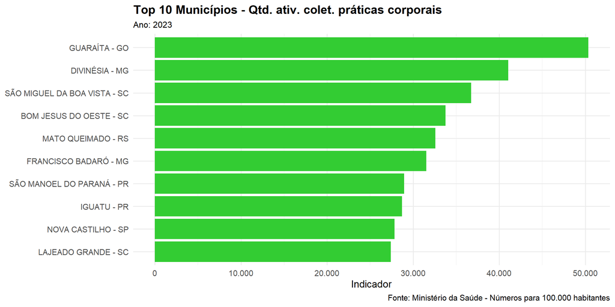

# 5.8 Indicadores atividades coletivas de verificação de saúde Vacinal

## Dados por UF

| UF | Regiao | Indicador | Media | Mediana | Desvio_pad | Minimo | Maximo | Pvalor_shapiro | Numerador | Denominador | num_municip |
| --- | --- | --- | --- | --- | --- | --- | --- | --- | --- | --- | --- |
| DISTRITO FEDERAL | CENTRO-OESTE | 57.38 | 57.38 | 57.38 | NA | 57.38 | 57.38 | NA | 1200 | 2091149 | 1 |
| GOIAS | CENTRO-OESTE | 85.20 | 118.28 | 44.19 | 167.78 | 0.00 | 919.36 | 0.00000 | 4503 | 5285178 | 231 |
| MATO GROSSO | CENTRO-OESTE | 121.20 | 127.42 | 54.47 | 205.81 | 0.00 | 1313.48 | 0.00000 | 3723 | 3071752 | 138 |
| MATO GROSSO DO SUL | CENTRO-OESTE | 92.59 | 110.11 | 60.37 | 171.32 | 0.00 | 1035.16 | 0.00000 | 2290 | 2473265 | 78 |
| ALAGOAS | NORDESTE | 104.95 | 150.74 | 61.66 | 214.43 | 0.00 | 1007.48 | 0.00000 | 2679 | 2552709 | 102 |
| BAHIA | NORDESTE | 94.40 | 133.92 | 51.44 | 238.28 | 0.00 | 2549.34 | 0.00000 | 11217 | 11882677 | 397 |
| CEARA | NORDESTE | 85.10 | 144.85 | 78.60 | 188.55 | 0.00 | 1117.77 | 0.00000 | 7438 | 8740685 | 182 |
| MARANHAO | NORDESTE | 162.67 | 197.77 | 110.46 | 252.85 | 0.00 | 2045.06 | 0.00000 | 9723 | 5977174 | 209 |
| PARAIBA | NORDESTE | 126.36 | 170.54 | 66.97 | 375.31 | 0.00 | 2750.22 | 0.00000 | 4705 | 3723470 | 212 |
| PERNAMBUCO | NORDESTE | 102.46 | 152.95 | 78.84 | 213.23 | 0.00 | 1460.76 | 0.00000 | 7720 | 7534514 | 185 |
| PIAUI | NORDESTE | 86.29 | 131.86 | 50.77 | 196.25 | 0.00 | 1042.79 | 0.00000 | 2706 | 3136094 | 207 |
| RIO GRANDE DO NORTE | NORDESTE | 142.22 | 206.15 | 103.19 | 289.36 | 0.00 | 2237.95 | 0.00000 | 4090 | 2875806 | 166 |
| SERGIPE | NORDESTE | 84.88 | 119.03 | 73.32 | 159.28 | 0.00 | 868.54 | 0.00000 | 1856 | 2186702 | 73 |
| ACRE | NORTE | 94.48 | 106.49 | 23.09 | 162.64 | 0.00 | 543.55 | 0.00002 | 652 | 690071 | 21 |
| AMAPA | NORTE | 280.81 | 335.10 | 253.21 | 356.26 | 0.00 | 1440.45 | 0.00104 | 1336 | 475774 | 16 |
| AMAZONAS | NORTE | 334.34 | 743.19 | 313.99 | 1816.67 | 0.00 | 10153.85 | 0.00000 | 10532 | 3150059 | 60 |
| PARA | NORTE | 226.40 | 288.54 | 130.78 | 520.37 | 0.00 | 4414.94 | 0.00000 | 12930 | 5711063 | 138 |
| RONDONIA | NORTE | 144.40 | 159.74 | 114.03 | 235.04 | 0.00 | 1645.50 | 0.00000 | 2045 | 1416214 | 52 |
| RORAIMA | NORTE | 51.27 | 51.96 | 19.90 | 89.72 | 0.00 | 316.27 | 0.00019 | 260 | 507119 | 12 |
| TOCANTINS | NORTE | 121.99 | 188.26 | 63.79 | 346.91 | 0.00 | 2322.40 | 0.00000 | 1764 | 1445992 | 126 |
| ESPIRITO SANTO | SUDESTE | 45.18 | 71.33 | 32.87 | 117.20 | 0.00 | 577.56 | 0.00000 | 1005 | 2224465 | 31 |
| MINAS GERAIS | SUDESTE | 69.78 | 114.90 | 44.09 | 202.79 | 0.00 | 1977.19 | 0.00000 | 13381 | 19175304 | 844 |
| RIO DE JANEIRO | SUDESTE | 65.24 | 50.73 | 30.48 | 60.68 | 0.00 | 258.19 | 0.00000 | 7503 | 11501317 | 87 |
| SAO PAULO | SUDESTE | 37.31 | 60.95 | 5.05 | 143.75 | 0.00 | 1273.21 | 0.00000 | 10914 | 29253025 | 553 |
| PARANA | SUL | 47.01 | 77.08 | 7.21 | 234.30 | 0.00 | 3600.65 | 0.00000 | 4681 | 9957845 | 364 |
| RIO GRANDE DO SUL | SUL | 108.18 | 158.57 | 50.86 | 289.03 | 0.00 | 2970.77 | 0.00000 | 9576 | 8852111 | 478 |
| SANTA CATARINA | SUL | 51.86 | 129.70 | 19.92 | 263.28 | 0.00 | 1659.90 | 0.00000 | 3564 | 6872446 | 269 |

Note:  
*A coluna indicador foi calculada pela divisão do total de praticas adotadas (por UF, Regiao ou país) pela coluna de total de população cadastrada no IBGE.

## Dados por Regiao

| Regiao | Indicador | Media | Mediana | Desvio_padrao | Minimo | Maximo | Pvalor_shapiro | numerador | Denominador | num_municip |
| --- | --- | --- | --- | --- | --- | --- | --- | --- | --- | --- |
| CENTRO-OESTE | 90.67 | 26.15 | 50.11 | 180.47 | 0 | 1313.48 | 0 | 11716 | 12921344 | 448 |
| NORDESTE | 107.25 | 30.08 | 71.36 | 251.77 | 0 | 2750.22 | 0 | 52134 | 48609831 | 1733 |
| NORTE | 220.35 | 69.46 | 111.24 | 795.21 | 0 | 10153.85 | 0 | 29519 | 13396292 | 425 |
| SUDESTE | 52.78 | 21.65 | 26.54 | 177.94 | 0 | 1977.19 | 0 | 32803 | 62154111 | 1515 |
| SUL | 69.39 | 16.04 | 26.58 | 268.01 | 0 | 3600.65 | 0 | 17821 | 25682402 | 1111 |

Note:  
*A coluna indicador foi calculada pela divisão do total de práticas adotadas (por UF, Regiao ou país) pela coluna de população cadastrada segundo o IBGE.

## Dados Nacionais

| Pais | Indicador | Media | Mediana | Desvio_padrao | Minimo | Maximo | Pvalor_shapiro | Numerador | Denominador | n_municip |
| --- | --- | --- | --- | --- | --- | --- | --- | --- | --- | --- |
| Brasil | 88.47 | 138.6 | 46.46 | 319.72 | 0 | 10153.85 | NA | 143993 | 162763980 | 5232 |

Note:  
*A coluna indicador foi calculada pela divisão do total de práticas adotadas (por UF, Regiao ou país) pela população cadastrada segundo o IBGE.

## Gráficos

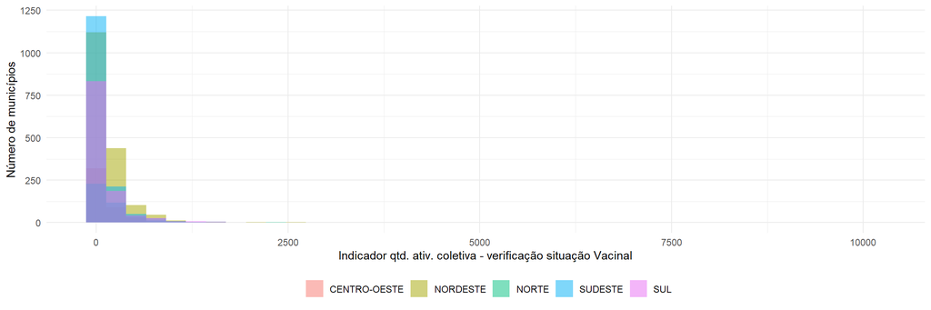

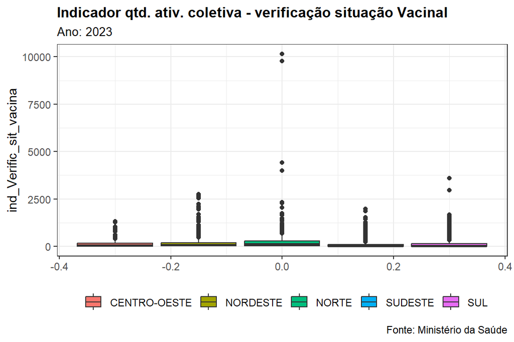

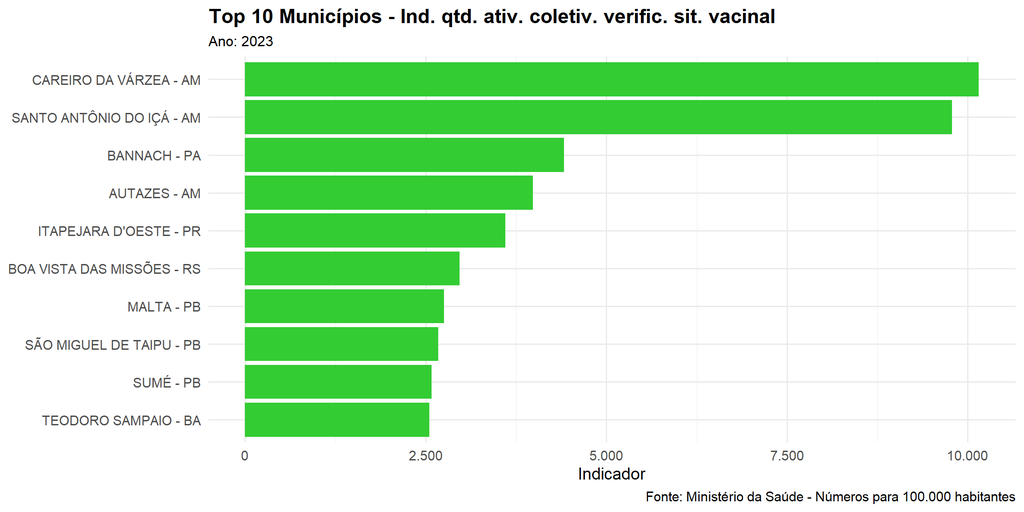